# Risk Factor Analysis

## Outcome Variable

**Outcome Variable:** ever_stunted

## Predictor Variables

**Intervention Variable:** tr

**Adjustment Set:**

unadjusted

## Stratifying Variables

The analysis was stratified on these variable(s):

- hfoodsec
- agecat
- studyid
- country

## Data Summary

| hfoodsec | agecat | studyid | country | tr | ever_stunted | n_cell | n |
| --- | --- | --- | --- | --- | --- | --- | --- |
| Food Secure | 0-6 months | ki1000110-WASH-Bangladesh | BANGLADESH | Control | 0 | 29 | 172 |
| Food Secure | 0-6 months | ki1000110-WASH-Bangladesh | BANGLADESH | Control | 1 | 5 | 172 |
| Food Secure | 0-6 months | ki1000110-WASH-Bangladesh | BANGLADESH | LNS | 0 | 47 | 172 |
| Food Secure | 0-6 months | ki1000110-WASH-Bangladesh | BANGLADESH | LNS | 1 | 3 | 172 |
| Food Secure | 0-6 months | ki1000110-WASH-Bangladesh | BANGLADESH | Other | 0 | 82 | 172 |
| Food Secure | 0-6 months | ki1000110-WASH-Bangladesh | BANGLADESH | Other | 1 | 6 | 172 |
| Mildly Food Insecure | 0-6 months | ki1000110-WASH-Bangladesh | BANGLADESH | Control | 0 | 2 | 12 |
| Mildly Food Insecure | 0-6 months | ki1000110-WASH-Bangladesh | BANGLADESH | LNS | 0 | 4 | 12 |
| Mildly Food Insecure | 0-6 months | ki1000110-WASH-Bangladesh | BANGLADESH | Other | 0 | 6 | 12 |
| Moderately Food Insecure | 0-6 months | ki1000110-WASH-Bangladesh | BANGLADESH | Control | 0 | 5 | 40 |
| Moderately Food Insecure | 0-6 months | ki1000110-WASH-Bangladesh | BANGLADESH | Control | 1 | 1 | 40 |
| Moderately Food Insecure | 0-6 months | ki1000110-WASH-Bangladesh | BANGLADESH | LNS | 0 | 10 | 40 |
| Moderately Food Insecure | 0-6 months | ki1000110-WASH-Bangladesh | BANGLADESH | LNS | 1 | 1 | 40 |
| Moderately Food Insecure | 0-6 months | ki1000110-WASH-Bangladesh | BANGLADESH | Other | 0 | 21 | 40 |
| Moderately Food Insecure | 0-6 months | ki1000110-WASH-Bangladesh | BANGLADESH | Other | 1 | 2 | 40 |
| Severely Food Insecure | 0-6 months | ki1000110-WASH-Bangladesh | BANGLADESH | Control | 0 | 1 | 8 |
| Severely Food Insecure | 0-6 months | ki1000110-WASH-Bangladesh | BANGLADESH | Control | 1 | 0 | 8 |
| Severely Food Insecure | 0-6 months | ki1000110-WASH-Bangladesh | BANGLADESH | LNS | 0 | 1 | 8 |
| Severely Food Insecure | 0-6 months | ki1000110-WASH-Bangladesh | BANGLADESH | LNS | 1 | 3 | 8 |
| Severely Food Insecure | 0-6 months | ki1000110-WASH-Bangladesh | BANGLADESH | Other | 0 | 1 | 8 |
| Severely Food Insecure | 0-6 months | ki1000110-WASH-Bangladesh | BANGLADESH | Other | 1 | 2 | 8 |
| Food Secure | 0-6 months | ki1148112-iLiNS-DOSE | MALAWI | Control | 0 | 37 | 252 |
| Food Secure | 0-6 months | ki1148112-iLiNS-DOSE | MALAWI | Control | 1 | 8 | 252 |
| Food Secure | 0-6 months | ki1148112-iLiNS-DOSE | MALAWI | LNS | 0 | 153 | 252 |
| Food Secure | 0-6 months | ki1148112-iLiNS-DOSE | MALAWI | LNS | 1 | 54 | 252 |
| Mildly Food Insecure | 0-6 months | ki1148112-iLiNS-DOSE | MALAWI | Control | 0 | 6 | 86 |
| Mildly Food Insecure | 0-6 months | ki1148112-iLiNS-DOSE | MALAWI | Control | 1 | 6 | 86 |
| Mildly Food Insecure | 0-6 months | ki1148112-iLiNS-DOSE | MALAWI | LNS | 0 | 46 | 86 |
| Mildly Food Insecure | 0-6 months | ki1148112-iLiNS-DOSE | MALAWI | LNS | 1 | 28 | 86 |
| Severely Food Insecure | 0-6 months | ki1148112-iLiNS-DOSE | MALAWI | Control | 0 | 54 | 542 |

[output cut: 266 more lines]

The following strata were considered:

- hfoodsec: Food Secure, agecat: 0-24 months, studyid: iLiNS_DYADM_LNS, country: MALAWI
- hfoodsec: Food Secure, agecat: 0-24 months, studyid: ki1000110-WASH-Bangladesh, country: BANGLADESH
- hfoodsec: Food Secure, agecat: 0-24 months, studyid: ki1148112-iLiNS-DOSE, country: MALAWI
- hfoodsec: Food Secure, agecat: 0-24 months, studyid: ki1148112-iLiNS-DYAD-M, country: MALAWI
- hfoodsec: Food Secure, agecat: 0-24 months, studyid: kiGH5241-JiVitA-3, country: BANGLADESH
- hfoodsec: Food Secure, agecat: 0-24 months, studyid: kiGH5241-JiVitA-4, country: BANGLADESH
- hfoodsec: Food Secure, agecat: 0-6 months, studyid: iLiNS_DYADM_LNS, country: MALAWI
- hfoodsec: Food Secure, agecat: 0-6 months, studyid: ki1000110-WASH-Bangladesh, country: BANGLADESH
- hfoodsec: Food Secure, agecat: 0-6 months, studyid: ki1148112-iLiNS-DOSE, country: MALAWI
- hfoodsec: Food Secure, agecat: 0-6 months, studyid: ki1148112-iLiNS-DYAD-M, country: MALAWI
- hfoodsec: Food Secure, agecat: 0-6 months, studyid: kiGH5241-JiVitA-3, country: BANGLADESH
- hfoodsec: Food Secure, agecat: 0-6 months, studyid: kiGH5241-JiVitA-4, country: BANGLADESH
- hfoodsec: Food Secure, agecat: 6-24 months, studyid: iLiNS_DYADM_LNS, country: MALAWI
- hfoodsec: Food Secure, agecat: 6-24 months, studyid: ki1000110-WASH-Bangladesh, country: BANGLADESH
- hfoodsec: Food Secure, agecat: 6-24 months, studyid: ki1148112-iLiNS-DOSE, country: MALAWI
- hfoodsec: Food Secure, agecat: 6-24 months, studyid: ki1148112-iLiNS-DYAD-M, country: MALAWI
- hfoodsec: Food Secure, agecat: 6-24 months, studyid: kiGH5241-JiVitA-3, country: BANGLADESH
- hfoodsec: Food Secure, agecat: 6-24 months, studyid: kiGH5241-JiVitA-4, country: BANGLADESH
- hfoodsec: Mildly Food Insecure, agecat: 0-24 months, studyid: iLiNS_DYADM_LNS, country: MALAWI
- hfoodsec: Mildly Food Insecure, agecat: 0-24 months, studyid: ki1000110-WASH-Bangladesh, country: BANGLADESH
- hfoodsec: Mildly Food Insecure, agecat: 0-24 months, studyid: ki1148112-iLiNS-DOSE, country: MALAWI
- hfoodsec: Mildly Food Insecure, agecat: 0-24 months, studyid: ki1148112-iLiNS-DYAD-M, country: MALAWI
- hfoodsec: Mildly Food Insecure, agecat: 0-24 months, studyid: kiGH5241-JiVitA-3, country: BANGLADESH
- hfoodsec: Mildly Food Insecure, agecat: 0-24 months, studyid: kiGH5241-JiVitA-4, country: BANGLADESH
- hfoodsec: Mildly Food Insecure, agecat: 0-6 months, studyid: iLiNS_DYADM_LNS, country: MALAWI
- hfoodsec: Mildly Food Insecure, agecat: 0-6 months, studyid: ki1000110-WASH-Bangladesh, country: BANGLADESH
- hfoodsec: Mildly Food Insecure, agecat: 0-6 months, studyid: ki1148112-iLiNS-DOSE, country: MALAWI
- hfoodsec: Mildly Food Insecure, agecat: 0-6 months, studyid: ki1148112-iLiNS-DYAD-M, country: MALAWI
- hfoodsec: Mildly Food Insecure, agecat: 0-6 months, studyid: kiGH5241-JiVitA-3, country: BANGLADESH
- hfoodsec: Mildly Food Insecure, agecat: 0-6 months, studyid: kiGH5241-JiVitA-4, country: BANGLADESH
- hfoodsec: Mildly Food Insecure, agecat: 6-24 months, studyid: iLiNS_DYADM_LNS, country: MALAWI
- hfoodsec: Mildly Food Insecure, agecat: 6-24 months, studyid: ki1000110-WASH-Bangladesh, country: BANGLADESH
- hfoodsec: Mildly Food Insecure, agecat: 6-24 months, studyid: ki1148112-iLiNS-DOSE, country: MALAWI
- hfoodsec: Mildly Food Insecure, agecat: 6-24 months, studyid: ki1148112-iLiNS-DYAD-M, country: MALAWI
- hfoodsec: Mildly Food Insecure, agecat: 6-24 months, studyid: kiGH5241-JiVitA-3, country: BANGLADESH
- hfoodsec: Mildly Food Insecure, agecat: 6-24 months, studyid: kiGH5241-JiVitA-4, country: BANGLADESH
- hfoodsec: Moderately Food Insecure, agecat: 0-24 months, studyid: iLiNS_DYADM_LNS, country: MALAWI
- hfoodsec: Moderately Food Insecure, agecat: 0-24 months, studyid: ki1000110-WASH-Bangladesh, country: BANGLADESH
- hfoodsec: Moderately Food Insecure, agecat: 0-24 months, studyid: ki1148112-iLiNS-DOSE, country: MALAWI
- hfoodsec: Moderately Food Insecure, agecat: 0-24 months, studyid: ki1148112-iLiNS-DYAD-M, country: MALAWI
- hfoodsec: Moderately Food Insecure, agecat: 0-24 months, studyid: kiGH5241-JiVitA-3, country: BANGLADESH
- hfoodsec: Moderately Food Insecure, agecat: 0-24 months, studyid: kiGH5241-JiVitA-4, country: BANGLADESH
- hfoodsec: Moderately Food Insecure, agecat: 0-6 months, studyid: iLiNS_DYADM_LNS, country: MALAWI
- hfoodsec: Moderately Food Insecure, agecat: 0-6 months, studyid: ki1000110-WASH-Bangladesh, country: BANGLADESH
- hfoodsec: Moderately Food Insecure, agecat: 0-6 months, studyid: ki1148112-iLiNS-DOSE, country: MALAWI
- hfoodsec: Moderately Food Insecure, agecat: 0-6 months, studyid: ki1148112-iLiNS-DYAD-M, country: MALAWI
- hfoodsec: Moderately Food Insecure, agecat: 0-6 months, studyid: kiGH5241-JiVitA-3, country: BANGLADESH
- hfoodsec: Moderately Food Insecure, agecat: 0-6 months, studyid: kiGH5241-JiVitA-4, country: BANGLADESH
- hfoodsec: Moderately Food Insecure, agecat: 6-24 months, studyid: iLiNS_DYADM_LNS, country: MALAWI
- hfoodsec: Moderately Food Insecure, agecat: 6-24 months, studyid: ki1000110-WASH-Bangladesh, country: BANGLADESH
- hfoodsec: Moderately Food Insecure, agecat: 6-24 months, studyid: ki1148112-iLiNS-DOSE, country: MALAWI
- hfoodsec: Moderately Food Insecure, agecat: 6-24 months, studyid: ki1148112-iLiNS-DYAD-M, country: MALAWI
- hfoodsec: Moderately Food Insecure, agecat: 6-24 months, studyid: kiGH5241-JiVitA-3, country: BANGLADESH
- hfoodsec: Moderately Food Insecure, agecat: 6-24 months, studyid: kiGH5241-JiVitA-4, country: BANGLADESH
- hfoodsec: Severely Food Insecure, agecat: 0-24 months, studyid: iLiNS_DYADM_LNS, country: MALAWI
- hfoodsec: Severely Food Insecure, agecat: 0-24 months, studyid: ki1000110-WASH-Bangladesh, country: BANGLADESH
- hfoodsec: Severely Food Insecure, agecat: 0-24 months, studyid: ki1148112-iLiNS-DOSE, country: MALAWI
- hfoodsec: Severely Food Insecure, agecat: 0-24 months, studyid: ki1148112-iLiNS-DYAD-M, country: MALAWI
- hfoodsec: Severely Food Insecure, agecat: 0-6 months, studyid: iLiNS_DYADM_LNS, country: MALAWI
- hfoodsec: Severely Food Insecure, agecat: 0-6 months, studyid: ki1000110-WASH-Bangladesh, country: BANGLADESH
- hfoodsec: Severely Food Insecure, agecat: 0-6 months, studyid: ki1148112-iLiNS-DOSE, country: MALAWI
- hfoodsec: Severely Food Insecure, agecat: 0-6 months, studyid: ki1148112-iLiNS-DYAD-M, country: MALAWI
- hfoodsec: Severely Food Insecure, agecat: 6-24 months, studyid: iLiNS_DYADM_LNS, country: MALAWI
- hfoodsec: Severely Food Insecure, agecat: 6-24 months, studyid: ki1000110-WASH-Bangladesh, country: BANGLADESH
- hfoodsec: Severely Food Insecure, agecat: 6-24 months, studyid: ki1148112-iLiNS-DOSE, country: MALAWI
- hfoodsec: Severely Food Insecure, agecat: 6-24 months, studyid: ki1148112-iLiNS-DYAD-M, country: MALAWI

### Dropped Strata

Some strata were dropped due to rare outcomes:

- hfoodsec: Food Secure, agecat: 0-6 months, studyid: ki1000110-WASH-Bangladesh, country: BANGLADESH
- hfoodsec: Mildly Food Insecure, agecat: 0-6 months, studyid: ki1000110-WASH-Bangladesh, country: BANGLADESH
- hfoodsec: Moderately Food Insecure, agecat: 0-6 months, studyid: ki1000110-WASH-Bangladesh, country: BANGLADESH
- hfoodsec: Severely Food Insecure, agecat: 0-6 months, studyid: ki1000110-WASH-Bangladesh, country: BANGLADESH
- hfoodsec: Mildly Food Insecure, agecat: 0-6 months, studyid: ki1148112-iLiNS-DYAD-M, country: MALAWI
- hfoodsec: Moderately Food Insecure, agecat: 0-6 months, studyid: ki1148112-iLiNS-DYAD-M, country: MALAWI
- hfoodsec: Severely Food Insecure, agecat: 0-6 months, studyid: ki1148112-iLiNS-DYAD-M, country: MALAWI
- hfoodsec: Food Secure, agecat: 0-6 months, studyid: ki1148112-iLiNS-DYAD-M, country: MALAWI
- hfoodsec: Mildly Food Insecure, agecat: 6-24 months, studyid: ki1148112-iLiNS-DOSE, country: MALAWI
- hfoodsec: Mildly Food Insecure, agecat: 0-6 months, studyid: iLiNS_DYADM_LNS, country: MALAWI
- hfoodsec: Severely Food Insecure, agecat: 0-6 months, studyid: iLiNS_DYADM_LNS, country: MALAWI
- hfoodsec: Moderately Food Insecure, agecat: 0-6 months, studyid: iLiNS_DYADM_LNS, country: MALAWI
- hfoodsec: Food Secure, agecat: 0-6 months, studyid: iLiNS_DYADM_LNS, country: MALAWI

## Methods Detail

We’re interested in the causal parameters $E[Y_a]$ for all values of $a \in \mathcal{A}$. These parameters represent the mean outcome if, possibly contrary to fact, we intervened to set all units to have $A=a$. Under the randomization and positivity assumptions, these are identified by the statistical parameters $\psi_a=E_W[E_{Y|A,W}(Y|A=a,W)]$. In addition, we’re interested in the mean of $Y$, $E[Y]$ under no intervention (the observed mean). We will estimate these parameters by using SuperLearner to fit the relevant likelihood factors – $E_{Y|A,W}(Y|A=a,W)$ and $p(A=a|W)$, and then updating our likelihood fit using a joint TMLE.

For unadjusted analyses ($W=\{\}$), initial likelihoods were estimated using Lrnr_glm to estimate the simple $E(Y|A)$ and Lrnr_mean to estimate $p(A)$. For adjusted analyses, a small library containing Lrnr_glmnet, Lrnr_xgboost, and Lrnr_mean was used.

Having estimated these parameters, we will then use the delta method to estimate relative risks and attributable risks relative to a prespecified baseline level of $A$.

# Results Detail

## Results Plots

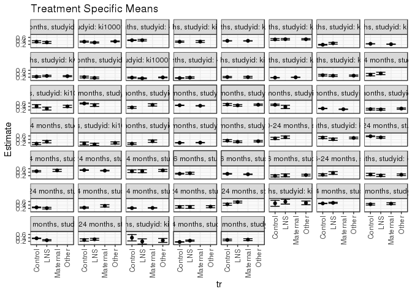

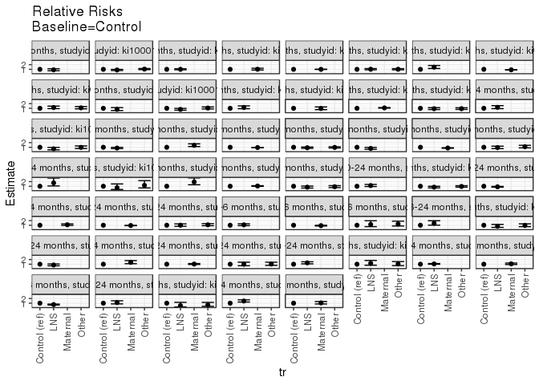

[figure not shown]

[figure not shown]

## Results Table

### Parameter: TSM

| hfoodsec | agecat | studyid | country | intervention_level | baseline_level | estimate | ci_lower | ci_upper |
| --- | --- | --- | --- | --- | --- | --- | --- | --- |
| Food Secure | 0-24 months | iLiNS_DYADM_LNS | MALAWI | Control | NA | 0.3529412 | 0.2975738 | 0.4083086 |
| Food Secure | 0-24 months | iLiNS_DYADM_LNS | MALAWI | LNS | NA | 0.3150685 | 0.2594804 | 0.3706566 |
| Food Secure | 0-24 months | ki1000110-WASH-Bangladesh | BANGLADESH | Control | NA | 0.3558052 | 0.3226455 | 0.3889650 |
| Food Secure | 0-24 months | ki1000110-WASH-Bangladesh | BANGLADESH | LNS | NA | 0.3070588 | 0.2760445 | 0.3380732 |
| Food Secure | 0-24 months | ki1000110-WASH-Bangladesh | BANGLADESH | Other | NA | 0.3729216 | 0.3498216 | 0.3960216 |
| Food Secure | 0-24 months | ki1148112-iLiNS-DOSE | MALAWI | Control | NA | 0.4383562 | 0.4175574 | 0.4591549 |
| Food Secure | 0-24 months | ki1148112-iLiNS-DOSE | MALAWI | LNS | NA | 0.4403670 | 0.3963252 | 0.4844087 |
| Food Secure | 0-24 months | ki1148112-iLiNS-DYAD-M | MALAWI | Control | NA | 0.3529412 | 0.3147993 | 0.3910830 |
| Food Secure | 0-24 months | ki1148112-iLiNS-DYAD-M | MALAWI | Maternal | NA | 0.3602941 | 0.3062178 | 0.4143704 |
| Food Secure | 0-24 months | kiGH5241-JiVitA-3 | BANGLADESH | Control | NA | 0.4039352 | 0.3957122 | 0.4121581 |
| Food Secure | 0-24 months | kiGH5241-JiVitA-3 | BANGLADESH | Maternal | NA | 0.4035410 | 0.3945626 | 0.4125195 |
| Food Secure | 0-24 months | kiGH5241-JiVitA-4 | BANGLADESH | Control | NA | 0.4851351 | 0.4383634 | 0.5319068 |
| Food Secure | 0-24 months | kiGH5241-JiVitA-4 | BANGLADESH | LNS | NA | 0.4960836 | 0.4541569 | 0.5380102 |
| Food Secure | 0-24 months | kiGH5241-JiVitA-4 | BANGLADESH | Other | NA | 0.4947707 | 0.4602019 | 0.5293396 |
| Food Secure | 0-6 months | ki1148112-iLiNS-DOSE | MALAWI | Control | NA | 0.1777778 | 0.1577906 | 0.1977649 |
| Food Secure | 0-6 months | ki1148112-iLiNS-DOSE | MALAWI | LNS | NA | 0.2608696 | 0.2116352 | 0.3101039 |
| Food Secure | 0-6 months | kiGH5241-JiVitA-3 | BANGLADESH | Control | NA | 0.2315728 | 0.2231296 | 0.2400161 |
| Food Secure | 0-6 months | kiGH5241-JiVitA-3 | BANGLADESH | Maternal | NA | 0.2074421 | 0.2001088 | 0.2147754 |
| Food Secure | 0-6 months | kiGH5241-JiVitA-4 | BANGLADESH | Control | NA | 0.2320261 | 0.1906645 | 0.2733877 |
| Food Secure | 0-6 months | kiGH5241-JiVitA-4 | BANGLADESH | LNS | NA | 0.2717391 | 0.2327801 | 0.3106982 |
| Food Secure | 0-6 months | kiGH5241-JiVitA-4 | BANGLADESH | Other | NA | 0.2570888 | 0.2261657 | 0.2880120 |
| Food Secure | 6-24 months | iLiNS_DYADM_LNS | MALAWI | Control | NA | 0.2068966 | 0.1558708 | 0.2579223 |
| Food Secure | 6-24 months | iLiNS_DYADM_LNS | MALAWI | LNS | NA | 0.1612903 | 0.1134649 | 0.2091158 |
| Food Secure | 6-24 months | ki1000110-WASH-Bangladesh | BANGLADESH | Control | NA | 0.1765625 | 0.1470161 | 0.2061089 |
| Food Secure | 6-24 months | ki1000110-WASH-Bangladesh | BANGLADESH | LNS | NA | 0.1354467 | 0.1099825 | 0.1609109 |
| Food Secure | 6-24 months | ki1000110-WASH-Bangladesh | BANGLADESH | Other | NA | 0.1866969 | 0.1656957 | 0.2076981 |
| Food Secure | 6-24 months | ki1148112-iLiNS-DOSE | MALAWI | Control | NA | 0.1509434 | 0.1321289 | 0.1697579 |
| Food Secure | 6-24 months | ki1148112-iLiNS-DOSE | MALAWI | LNS | NA | 0.1780822 | 0.1372102 | 0.2189542 |
| Food Secure | 6-24 months | ki1148112-iLiNS-DYAD-M | MALAWI | Control | NA | 0.2068966 | 0.1716399 | 0.2421532 |
| Food Secure | 6-24 months | ki1148112-iLiNS-DYAD-M | MALAWI | Maternal | NA | 0.2000000 | 0.1510312 | 0.2489688 |

[output cut: 93 more lines]

### Parameter: E(Y)

| hfoodsec | agecat | studyid | country | intervention_level | baseline_level | estimate | ci_lower | ci_upper |
| --- | --- | --- | --- | --- | --- | --- | --- | --- |
| Food Secure | 0-24 months | iLiNS_DYADM_LNS | MALAWI | NA | NA | 0.3333333 | 0.2548273 | 0.4118394 |
| Food Secure | 0-24 months | ki1000110-WASH-Bangladesh | BANGLADESH | NA | NA | 0.3520240 | 0.3358122 | 0.3682358 |
| Food Secure | 0-24 months | ki1148112-iLiNS-DOSE | MALAWI | NA | NA | 0.4400000 | 0.3912941 | 0.4887059 |
| Food Secure | 0-24 months | ki1148112-iLiNS-DYAD-M | MALAWI | NA | NA | 0.3578431 | 0.2916658 | 0.4240205 |
| Food Secure | 0-24 months | kiGH5241-JiVitA-3 | BANGLADESH | NA | NA | 0.4037375 | 0.3915647 | 0.4159102 |
| Food Secure | 0-24 months | kiGH5241-JiVitA-4 | BANGLADESH | NA | NA | 0.4925427 | 0.4693232 | 0.5157623 |
| Food Secure | 0-6 months | ki1148112-iLiNS-DOSE | MALAWI | NA | NA | 0.2460317 | 0.1927494 | 0.2993141 |
| Food Secure | 0-6 months | kiGH5241-JiVitA-3 | BANGLADESH | NA | NA | 0.2195655 | 0.2083210 | 0.2308101 |
| Food Secure | 0-6 months | kiGH5241-JiVitA-4 | BANGLADESH | NA | NA | 0.2545376 | 0.2336424 | 0.2754328 |
| Food Secure | 6-24 months | iLiNS_DYADM_LNS | MALAWI | NA | NA | 0.1833333 | 0.1132915 | 0.2533751 |
| Food Secure | 6-24 months | ki1000110-WASH-Bangladesh | BANGLADESH | NA | NA | 0.1708694 | 0.1565549 | 0.1851840 |
| Food Secure | 6-24 months | ki1148112-iLiNS-DOSE | MALAWI | NA | NA | 0.1727941 | 0.1277815 | 0.2178068 |
| Food Secure | 6-24 months | ki1148112-iLiNS-DYAD-M | MALAWI | NA | NA | 0.2023121 | 0.1419707 | 0.2626536 |
| Food Secure | 6-24 months | kiGH5241-JiVitA-3 | BANGLADESH | NA | NA | 0.1825822 | 0.1724683 | 0.1926962 |
| Food Secure | 6-24 months | kiGH5241-JiVitA-4 | BANGLADESH | NA | NA | 0.2956204 | 0.2714883 | 0.3197526 |
| Mildly Food Insecure | 0-24 months | iLiNS_DYADM_LNS | MALAWI | NA | NA | 0.3804348 | 0.2806852 | 0.4801843 |
| Mildly Food Insecure | 0-24 months | ki1000110-WASH-Bangladesh | BANGLADESH | NA | NA | 0.3785714 | 0.3321295 | 0.4250134 |
| Mildly Food Insecure | 0-24 months | ki1148112-iLiNS-DOSE | MALAWI | NA | NA | 0.4966443 | 0.4160921 | 0.5771965 |
| Mildly Food Insecure | 0-24 months | ki1148112-iLiNS-DYAD-M | MALAWI | NA | NA | 0.4384615 | 0.3528349 | 0.5240881 |
| Mildly Food Insecure | 0-24 months | kiGH5241-JiVitA-3 | BANGLADESH | NA | NA | 0.4587236 | 0.4421845 | 0.4752626 |
| Mildly Food Insecure | 0-24 months | kiGH5241-JiVitA-4 | BANGLADESH | NA | NA | 0.4974306 | 0.4704428 | 0.5244185 |
| Mildly Food Insecure | 0-6 months | ki1148112-iLiNS-DOSE | MALAWI | NA | NA | 0.3953488 | 0.2914092 | 0.4992885 |
| Mildly Food Insecure | 0-6 months | kiGH5241-JiVitA-3 | BANGLADESH | NA | NA | 0.2655539 | 0.2493628 | 0.2817449 |
| Mildly Food Insecure | 0-6 months | kiGH5241-JiVitA-4 | BANGLADESH | NA | NA | 0.2608430 | 0.2354079 | 0.2862782 |
| Mildly Food Insecure | 6-24 months | iLiNS_DYADM_LNS | MALAWI | NA | NA | 0.2054795 | 0.1121500 | 0.2988089 |
| Mildly Food Insecure | 6-24 months | ki1000110-WASH-Bangladesh | BANGLADESH | NA | NA | 0.1624204 | 0.1215594 | 0.2032814 |
| Mildly Food Insecure | 6-24 months | ki1148112-iLiNS-DYAD-M | MALAWI | NA | NA | 0.2400000 | 0.1558715 | 0.3241285 |
| Mildly Food Insecure | 6-24 months | kiGH5241-JiVitA-3 | BANGLADESH | NA | NA | 0.2066344 | 0.1920536 | 0.2212152 |
| Mildly Food Insecure | 6-24 months | kiGH5241-JiVitA-4 | BANGLADESH | NA | NA | 0.2933071 | 0.2655967 | 0.3210175 |
| Moderately Food Insecure | 0-24 months | iLiNS_DYADM_LNS | MALAWI | NA | NA | 0.4952381 | 0.3991473 | 0.5913289 |
| Moderately Food Insecure | 0-24 months | ki1000110-WASH-Bangladesh | BANGLADESH | NA | NA | 0.4716352 | 0.4389854 | 0.5042849 |
| Moderately Food Insecure | 0-24 months | ki1148112-iLiNS-DOSE | MALAWI | NA | NA | 0.5242967 | 0.4747320 | 0.5738614 |
| Moderately Food Insecure | 0-24 months | ki1148112-iLiNS-DYAD-M | MALAWI | NA | NA | 0.4916201 | 0.4181777 | 0.5650626 |
| Moderately Food Insecure | 0-24 months | kiGH5241-JiVitA-3 | BANGLADESH | NA | NA | 0.5064303 | 0.4822735 | 0.5305871 |
| Moderately Food Insecure | 0-24 months | kiGH5241-JiVitA-4 | BANGLADESH | NA | NA | 0.4807418 | 0.4395517 | 0.5219319 |
| Moderately Food Insecure | 0-6 months | ki1148112-iLiNS-DOSE | MALAWI | NA | NA | 0.3361702 | 0.2756434 | 0.3966971 |
| Moderately Food Insecure | 0-6 months | kiGH5241-JiVitA-3 | BANGLADESH | NA | NA | 0.2933217 | 0.2697137 | 0.3169297 |
| Moderately Food Insecure | 0-6 months | kiGH5241-JiVitA-4 | BANGLADESH | NA | NA | 0.2167235 | 0.1804186 | 0.2530285 |
| Moderately Food Insecure | 6-24 months | iLiNS_DYADM_LNS | MALAWI | NA | NA | 0.3095238 | 0.2100679 | 0.4089797 |
| Moderately Food Insecure | 6-24 months | ki1000110-WASH-Bangladesh | BANGLADESH | NA | NA | 0.2476780 | 0.2143650 | 0.2809910 |
| Moderately Food Insecure | 6-24 months | ki1148112-iLiNS-DOSE | MALAWI | NA | NA | 0.2261905 | 0.1744339 | 0.2779470 |
| Moderately Food Insecure | 6-24 months | ki1148112-iLiNS-DYAD-M | MALAWI | NA | NA | 0.3266667 | 0.2513619 | 0.4019714 |
| Moderately Food Insecure | 6-24 months | kiGH5241-JiVitA-3 | BANGLADESH | NA | NA | 0.2292899 | 0.2060345 | 0.2525454 |
| Moderately Food Insecure | 6-24 months | kiGH5241-JiVitA-4 | BANGLADESH | NA | NA | 0.2971530 | 0.2561989 | 0.3381071 |
| Severely Food Insecure | 0-24 months | iLiNS_DYADM_LNS | MALAWI | NA | NA | 0.4963504 | 0.4123198 | 0.5803809 |
| Severely Food Insecure | 0-24 months | ki1000110-WASH-Bangladesh | BANGLADESH | NA | NA | 0.5398773 | 0.4631279 | 0.6166267 |
| Severely Food Insecure | 0-24 months | ki1148112-iLiNS-DOSE | MALAWI | NA | NA | 0.5201422 | 0.4864172 | 0.5538672 |
| Severely Food Insecure | 0-24 months | ki1148112-iLiNS-DYAD-M | MALAWI | NA | NA | 0.4650000 | 0.3957013 | 0.5342987 |
| Severely Food Insecure | 0-6 months | ki1148112-iLiNS-DOSE | MALAWI | NA | NA | 0.2785978 | 0.2408208 | 0.3163747 |
| Severely Food Insecure | 6-24 months | iLiNS_DYADM_LNS | MALAWI | NA | NA | 0.2935780 | 0.2076905 | 0.3794655 |
| Severely Food Insecure | 6-24 months | ki1000110-WASH-Bangladesh | BANGLADESH | NA | NA | 0.2752294 | 0.1909960 | 0.3594627 |
| Severely Food Insecure | 6-24 months | ki1148112-iLiNS-DOSE | MALAWI | NA | NA | 0.2259887 | 0.1903824 | 0.2615950 |
| Severely Food Insecure | 6-24 months | ki1148112-iLiNS-DYAD-M | MALAWI | NA | NA | 0.2901235 | 0.2200235 | 0.3602235 |

### Parameter: RR

| hfoodsec | agecat | studyid | country | intervention_level | baseline_level | estimate | ci_lower | ci_upper |
| --- | --- | --- | --- | --- | --- | --- | --- | --- |
| Food Secure | 0-24 months | iLiNS_DYADM_LNS | MALAWI | Control | Control | 1.0000000 | 1.0000000 | 1.0000000 |
| Food Secure | 0-24 months | iLiNS_DYADM_LNS | MALAWI | LNS | Control | 0.8926941 | 0.7049702 | 1.1304062 |
| Food Secure | 0-24 months | ki1000110-WASH-Bangladesh | BANGLADESH | Control | Control | 1.0000000 | 1.0000000 | 1.0000000 |
| Food Secure | 0-24 months | ki1000110-WASH-Bangladesh | BANGLADESH | LNS | Control | 0.8629969 | 0.7521827 | 0.9901366 |
| Food Secure | 0-24 months | ki1000110-WASH-Bangladesh | BANGLADESH | Other | Control | 1.0481060 | 0.9371429 | 1.1722078 |
| Food Secure | 0-24 months | ki1148112-iLiNS-DOSE | MALAWI | Control | Control | 1.0000000 | 1.0000000 | 1.0000000 |
| Food Secure | 0-24 months | ki1148112-iLiNS-DOSE | MALAWI | LNS | Control | 1.0045872 | 0.8993176 | 1.1221790 |
| Food Secure | 0-24 months | ki1148112-iLiNS-DYAD-M | MALAWI | Control | Control | 1.0000000 | 1.0000000 | 1.0000000 |
| Food Secure | 0-24 months | ki1148112-iLiNS-DYAD-M | MALAWI | Maternal | Control | 1.0208333 | 0.8484634 | 1.2282212 |
| Food Secure | 0-24 months | kiGH5241-JiVitA-3 | BANGLADESH | Control | Control | 1.0000000 | 1.0000000 | 1.0000000 |
| Food Secure | 0-24 months | kiGH5241-JiVitA-3 | BANGLADESH | Maternal | Control | 0.9990242 | 0.9693406 | 1.0296169 |
| Food Secure | 0-24 months | kiGH5241-JiVitA-4 | BANGLADESH | Control | Control | 1.0000000 | 1.0000000 | 1.0000000 |
| Food Secure | 0-24 months | kiGH5241-JiVitA-4 | BANGLADESH | LNS | Control | 1.0225678 | 0.8995237 | 1.1624427 |
| Food Secure | 0-24 months | kiGH5241-JiVitA-4 | BANGLADESH | Other | Control | 1.0198616 | 0.9054077 | 1.1487839 |
| Food Secure | 0-6 months | ki1148112-iLiNS-DOSE | MALAWI | Control | Control | 1.0000000 | 1.0000000 | 1.0000000 |
| Food Secure | 0-6 months | ki1148112-iLiNS-DOSE | MALAWI | LNS | Control | 1.4673913 | 1.1779851 | 1.8278986 |
| Food Secure | 0-6 months | kiGH5241-JiVitA-3 | BANGLADESH | Control | Control | 1.0000000 | 1.0000000 | 1.0000000 |
| Food Secure | 0-6 months | kiGH5241-JiVitA-3 | BANGLADESH | Maternal | Control | 0.8957965 | 0.8514310 | 0.9424737 |
| Food Secure | 0-6 months | kiGH5241-JiVitA-4 | BANGLADESH | Control | Control | 1.0000000 | 1.0000000 | 1.0000000 |
| Food Secure | 0-6 months | kiGH5241-JiVitA-4 | BANGLADESH | LNS | Control | 1.1711574 | 0.9317620 | 1.4720601 |
| Food Secure | 0-6 months | kiGH5241-JiVitA-4 | BANGLADESH | Other | Control | 1.1080167 | 0.8936551 | 1.3737974 |
| Food Secure | 6-24 months | iLiNS_DYADM_LNS | MALAWI | Control | Control | 1.0000000 | 1.0000000 | 1.0000000 |
| Food Secure | 6-24 months | iLiNS_DYADM_LNS | MALAWI | LNS | Control | 0.7795699 | 0.5301001 | 1.1464424 |
| Food Secure | 6-24 months | ki1000110-WASH-Bangladesh | BANGLADESH | Control | Control | 1.0000000 | 1.0000000 | 1.0000000 |
| Food Secure | 6-24 months | ki1000110-WASH-Bangladesh | BANGLADESH | LNS | Control | 0.7671317 | 0.5964336 | 0.9866832 |
| Food Secure | 6-24 months | ki1000110-WASH-Bangladesh | BANGLADESH | Other | Control | 1.0573984 | 0.8643093 | 1.2936240 |
| Food Secure | 6-24 months | ki1148112-iLiNS-DOSE | MALAWI | Control | Control | 1.0000000 | 1.0000000 | 1.0000000 |
| Food Secure | 6-24 months | ki1148112-iLiNS-DOSE | MALAWI | LNS | Control | 1.1797945 | 0.9086144 | 1.5319096 |
| Food Secure | 6-24 months | ki1148112-iLiNS-DYAD-M | MALAWI | Control | Control | 1.0000000 | 1.0000000 | 1.0000000 |
| Food Secure | 6-24 months | ki1148112-iLiNS-DYAD-M | MALAWI | Maternal | Control | 0.9666667 | 0.7173375 | 1.3026565 |

[output cut: 93 more lines]

### Parameter: PAR

| hfoodsec | agecat | studyid | country | intervention_level | baseline_level | estimate | ci_lower | ci_upper |
| --- | --- | --- | --- | --- | --- | --- | --- | --- |
| Food Secure | 0-24 months | iLiNS_DYADM_LNS | MALAWI | Control | NA | -0.0196078 | -0.0752644 | 0.0360487 |
| Food Secure | 0-24 months | ki1000110-WASH-Bangladesh | BANGLADESH | Control | NA | -0.0037813 | -0.0326638 | 0.0251013 |
| Food Secure | 0-24 months | ki1148112-iLiNS-DOSE | MALAWI | Control | NA | 0.0016438 | -0.0423980 | 0.0456857 |
| Food Secure | 0-24 months | ki1148112-iLiNS-DYAD-M | MALAWI | Control | NA | 0.0049020 | -0.0491780 | 0.0589819 |
| Food Secure | 0-24 months | kiGH5241-JiVitA-3 | BANGLADESH | Control | NA | -0.0001977 | -0.0091767 | 0.0087813 |
| Food Secure | 0-24 months | kiGH5241-JiVitA-4 | BANGLADESH | Control | NA | 0.0074076 | -0.0319580 | 0.0467732 |
| Food Secure | 0-6 months | ki1148112-iLiNS-DOSE | MALAWI | Control | NA | 0.0682540 | 0.0188624 | 0.1176455 |
| Food Secure | 0-6 months | kiGH5241-JiVitA-3 | BANGLADESH | Control | NA | -0.0120073 | -0.0194474 | -0.0045672 |
| Food Secure | 0-6 months | kiGH5241-JiVitA-4 | BANGLADESH | Control | NA | 0.0225115 | -0.0127953 | 0.0578182 |
| Food Secure | 6-24 months | iLiNS_DYADM_LNS | MALAWI | Control | NA | -0.0235632 | -0.0715448 | 0.0244183 |
| Food Secure | 6-24 months | ki1000110-WASH-Bangladesh | BANGLADESH | Control | NA | -0.0056931 | -0.0313317 | 0.0199455 |
| Food Secure | 6-24 months | ki1148112-iLiNS-DOSE | MALAWI | Control | NA | 0.0218507 | -0.0190413 | 0.0627427 |
| Food Secure | 6-24 months | ki1148112-iLiNS-DYAD-M | MALAWI | Control | NA | -0.0045844 | -0.0535544 | 0.0443856 |
| Food Secure | 6-24 months | kiGH5241-JiVitA-3 | BANGLADESH | Control | NA | 0.0081977 | 0.0007111 | 0.0156843 |
| Food Secure | 6-24 months | kiGH5241-JiVitA-4 | BANGLADESH | Control | NA | -0.0184291 | -0.0577245 | 0.0208662 |
| Mildly Food Insecure | 0-24 months | iLiNS_DYADM_LNS | MALAWI | Control | NA | 0.0334960 | -0.0361879 | 0.1031799 |
| Mildly Food Insecure | 0-24 months | ki1000110-WASH-Bangladesh | BANGLADESH | Control | NA | -0.0404762 | -0.1218443 | 0.0408919 |
| Mildly Food Insecure | 0-24 months | ki1148112-iLiNS-DOSE | MALAWI | Control | NA | -0.0823031 | -0.1576810 | -0.0069251 |
| Mildly Food Insecure | 0-24 months | ki1148112-iLiNS-DYAD-M | MALAWI | Control | NA | 0.0915228 | 0.0223216 | 0.1607239 |
| Mildly Food Insecure | 0-24 months | kiGH5241-JiVitA-3 | BANGLADESH | Control | NA | -0.0133415 | -0.0246419 | -0.0020411 |
| Mildly Food Insecure | 0-24 months | kiGH5241-JiVitA-4 | BANGLADESH | Control | NA | -0.0201677 | -0.0697127 | 0.0293772 |
| Mildly Food Insecure | 0-6 months | ki1148112-iLiNS-DOSE | MALAWI | Control | NA | -0.1046512 | -0.2007081 | -0.0085942 |
| Mildly Food Insecure | 0-6 months | kiGH5241-JiVitA-3 | BANGLADESH | Control | NA | -0.0221904 | -0.0339026 | -0.0104781 |
| Mildly Food Insecure | 0-6 months | kiGH5241-JiVitA-4 | BANGLADESH | Control | NA | 0.0095867 | -0.0348217 | 0.0539951 |
| Mildly Food Insecure | 6-24 months | iLiNS_DYADM_LNS | MALAWI | Control | NA | 0.0516333 | -0.0190760 | 0.1223426 |
| Mildly Food Insecure | 6-24 months | ki1000110-WASH-Bangladesh | BANGLADESH | Control | NA | 0.0002582 | -0.0732958 | 0.0738122 |
| Mildly Food Insecure | 6-24 months | ki1148112-iLiNS-DYAD-M | MALAWI | Control | NA | 0.0861538 | 0.0146862 | 0.1576214 |
| Mildly Food Insecure | 6-24 months | kiGH5241-JiVitA-3 | BANGLADESH | Control | NA | 0.0051990 | -0.0048581 | 0.0152561 |
| Mildly Food Insecure | 6-24 months | kiGH5241-JiVitA-4 | BANGLADESH | Control | NA | -0.0339656 | -0.0848294 | 0.0168981 |
| Moderately Food Insecure | 0-24 months | iLiNS_DYADM_LNS | MALAWI | Control | NA | 0.0387164 | -0.0335231 | 0.1109558 |
| Moderately Food Insecure | 0-24 months | ki1000110-WASH-Bangladesh | BANGLADESH | Control | NA | -0.0325665 | -0.0870332 | 0.0219001 |
| Moderately Food Insecure | 0-24 months | ki1148112-iLiNS-DOSE | MALAWI | Control | NA | -0.0563485 | -0.1019154 | -0.0107815 |
| Moderately Food Insecure | 0-24 months | ki1148112-iLiNS-DYAD-M | MALAWI | Control | NA | 0.0350984 | -0.0282875 | 0.0984843 |
| Moderately Food Insecure | 0-24 months | kiGH5241-JiVitA-3 | BANGLADESH | Control | NA | -0.0150334 | -0.0321698 | 0.0021029 |
| Moderately Food Insecure | 0-24 months | kiGH5241-JiVitA-4 | BANGLADESH | Control | NA | 0.0219789 | -0.0434459 | 0.0874037 |
| Moderately Food Insecure | 0-6 months | ki1148112-iLiNS-DOSE | MALAWI | Control | NA | 0.0236702 | -0.0327499 | 0.0800903 |
| Moderately Food Insecure | 0-6 months | kiGH5241-JiVitA-3 | BANGLADESH | Control | NA | -0.0132862 | -0.0291580 | 0.0025856 |
| Moderately Food Insecure | 0-6 months | kiGH5241-JiVitA-4 | BANGLADESH | Control | NA | 0.0303881 | -0.0253068 | 0.0860831 |
| Moderately Food Insecure | 6-24 months | iLiNS_DYADM_LNS | MALAWI | Control | NA | 0.0595238 | -0.0190404 | 0.1380880 |
| Moderately Food Insecure | 6-24 months | ki1000110-WASH-Bangladesh | BANGLADESH | Control | NA | -0.0185942 | -0.0754305 | 0.0382422 |
| Moderately Food Insecure | 6-24 months | ki1148112-iLiNS-DOSE | MALAWI | Control | NA | -0.0369674 | -0.0842034 | 0.0102686 |
| Moderately Food Insecure | 6-24 months | ki1148112-iLiNS-DYAD-M | MALAWI | Control | NA | 0.0766667 | 0.0095054 | 0.1438279 |
| Moderately Food Insecure | 6-24 months | kiGH5241-JiVitA-3 | BANGLADESH | Control | NA | 0.0041108 | -0.0116268 | 0.0198484 |
| Moderately Food Insecure | 6-24 months | kiGH5241-JiVitA-4 | BANGLADESH | Control | NA | 0.0049452 | -0.0583103 | 0.0682008 |
| Severely Food Insecure | 0-24 months | iLiNS_DYADM_LNS | MALAWI | Control | NA | 0.0519059 | -0.0022939 | 0.1061058 |
| Severely Food Insecure | 0-24 months | ki1000110-WASH-Bangladesh | BANGLADESH | Control | NA | 0.0398773 | -0.1157851 | 0.1955397 |
| Severely Food Insecure | 0-24 months | ki1148112-iLiNS-DOSE | MALAWI | Control | NA | 0.0270866 | -0.0036224 | 0.0577956 |
| Severely Food Insecure | 0-24 months | ki1148112-iLiNS-DYAD-M | MALAWI | Control | NA | 0.0205556 | -0.0330348 | 0.0741459 |
| Severely Food Insecure | 0-6 months | ki1148112-iLiNS-DOSE | MALAWI | Control | NA | -0.0934952 | -0.1276107 | -0.0593798 |
| Severely Food Insecure | 6-24 months | iLiNS_DYADM_LNS | MALAWI | Control | NA | 0.0141662 | -0.0397684 | 0.0681008 |
| Severely Food Insecure | 6-24 months | ki1000110-WASH-Bangladesh | BANGLADESH | Control | NA | -0.1321780 | -0.2889835 | 0.0246274 |
| Severely Food Insecure | 6-24 months | ki1148112-iLiNS-DOSE | MALAWI | Control | NA | 0.0629452 | 0.0298326 | 0.0960579 |
| Severely Food Insecure | 6-24 months | ki1148112-iLiNS-DYAD-M | MALAWI | Control | NA | 0.0107117 | -0.0431169 | 0.0645403 |

### Parameter: PAF

| hfoodsec | agecat | studyid | country | intervention_level | baseline_level | estimate | ci_lower | ci_upper |
| --- | --- | --- | --- | --- | --- | --- | --- | --- |
| Food Secure | 0-24 months | iLiNS_DYADM_LNS | MALAWI | Control | NA | -0.0588235 | -0.2515500 | 0.1042249 |
| Food Secure | 0-24 months | ki1000110-WASH-Bangladesh | BANGLADESH | Control | NA | -0.0107415 | -0.0962109 | 0.0680641 |
| Food Secure | 0-24 months | ki1148112-iLiNS-DOSE | MALAWI | Control | NA | 0.0037360 | -0.1011468 | 0.0986289 |
| Food Secure | 0-24 months | ki1148112-iLiNS-DYAD-M | MALAWI | Control | NA | 0.0136986 | -0.1472198 | 0.1520454 |
| Food Secure | 0-24 months | kiGH5241-JiVitA-3 | BANGLADESH | Control | NA | -0.0004897 | -0.0229896 | 0.0215152 |
| Food Secure | 0-24 months | kiGH5241-JiVitA-4 | BANGLADESH | Control | NA | 0.0150395 | -0.0682609 | 0.0918444 |
| Food Secure | 0-6 months | ki1148112-iLiNS-DOSE | MALAWI | Control | NA | 0.2774194 | 0.1146438 | 0.4102681 |
| Food Secure | 0-6 months | kiGH5241-JiVitA-3 | BANGLADESH | Control | NA | -0.0546867 | -0.0910980 | -0.0194904 |
| Food Secure | 0-6 months | kiGH5241-JiVitA-4 | BANGLADESH | Control | NA | 0.0884406 | -0.0617577 | 0.2173916 |
| Food Secure | 6-24 months | iLiNS_DYADM_LNS | MALAWI | Control | NA | -0.1285266 | -0.4689430 | 0.1330008 |
| Food Secure | 6-24 months | ki1000110-WASH-Bangladesh | BANGLADESH | Control | NA | -0.0333184 | -0.1947901 | 0.1063310 |
| Food Secure | 6-24 months | ki1148112-iLiNS-DOSE | MALAWI | Control | NA | 0.1264552 | -0.1073613 | 0.3109020 |
| Food Secure | 6-24 months | ki1148112-iLiNS-DYAD-M | MALAWI | Control | NA | -0.0226601 | -0.3027659 | 0.1972206 |
| Food Secure | 6-24 months | kiGH5241-JiVitA-3 | BANGLADESH | Control | NA | 0.0448987 | 0.0048867 | 0.0833020 |
| Food Secure | 6-24 months | kiGH5241-JiVitA-4 | BANGLADESH | Control | NA | -0.0623406 | -0.2039517 | 0.0626140 |
| Mildly Food Insecure | 0-24 months | iLiNS_DYADM_LNS | MALAWI | Control | NA | 0.0880466 | -0.0962510 | 0.2413608 |
| Mildly Food Insecure | 0-24 months | ki1000110-WASH-Bangladesh | BANGLADESH | Control | NA | -0.1069182 | -0.3443085 | 0.0885515 |
| Mildly Food Insecure | 0-24 months | ki1148112-iLiNS-DOSE | MALAWI | Control | NA | -0.1657183 | -0.3570723 | -0.0013462 |
| Mildly Food Insecure | 0-24 months | ki1148112-iLiNS-DYAD-M | MALAWI | Control | NA | 0.2087361 | 0.0707771 | 0.3262128 |
| Mildly Food Insecure | 0-24 months | kiGH5241-JiVitA-3 | BANGLADESH | Control | NA | -0.0290840 | -0.0547584 | -0.0040345 |
| Mildly Food Insecure | 0-24 months | kiGH5241-JiVitA-4 | BANGLADESH | Control | NA | -0.0405438 | -0.1448911 | 0.0542932 |
| Mildly Food Insecure | 0-6 months | ki1148112-iLiNS-DOSE | MALAWI | Control | NA | -0.2647059 | -0.6139986 | 0.0089948 |
| Mildly Food Insecure | 0-6 months | kiGH5241-JiVitA-3 | BANGLADESH | Control | NA | -0.0835625 | -0.1325498 | -0.0366942 |
| Mildly Food Insecure | 0-6 months | kiGH5241-JiVitA-4 | BANGLADESH | Control | NA | 0.0367529 | -0.1494563 | 0.1927966 |
| Mildly Food Insecure | 6-24 months | iLiNS_DYADM_LNS | MALAWI | Control | NA | 0.2512821 | -0.0712435 | 0.4767030 |
| Mildly Food Insecure | 6-24 months | ki1000110-WASH-Bangladesh | BANGLADESH | Control | NA | 0.0015898 | -0.5714392 | 0.3656624 |
| Mildly Food Insecure | 6-24 months | ki1148112-iLiNS-DYAD-M | MALAWI | Control | NA | 0.3589744 | 0.1213856 | 0.5323160 |
| Mildly Food Insecure | 6-24 months | kiGH5241-JiVitA-3 | BANGLADESH | Control | NA | 0.0251604 | -0.0234779 | 0.0714874 |
| Mildly Food Insecure | 6-24 months | kiGH5241-JiVitA-4 | BANGLADESH | Control | NA | -0.1158023 | -0.3023791 | 0.0440458 |
| Moderately Food Insecure | 0-24 months | iLiNS_DYADM_LNS | MALAWI | Control | NA | 0.0781773 | -0.0670190 | 0.2036157 |
| Moderately Food Insecure | 0-24 months | ki1000110-WASH-Bangladesh | BANGLADESH | Control | NA | -0.0690503 | -0.1911035 | 0.0404961 |
| Moderately Food Insecure | 0-24 months | ki1148112-iLiNS-DOSE | MALAWI | Control | NA | -0.1074744 | -0.2081227 | -0.0152111 |
| Moderately Food Insecure | 0-24 months | ki1148112-iLiNS-DYAD-M | MALAWI | Control | NA | 0.0713933 | -0.0565334 | 0.1838304 |
| Moderately Food Insecure | 0-24 months | kiGH5241-JiVitA-3 | BANGLADESH | Control | NA | -0.0296851 | -0.0651372 | 0.0045869 |
| Moderately Food Insecure | 0-24 months | kiGH5241-JiVitA-4 | BANGLADESH | Control | NA | 0.0457187 | -0.1004898 | 0.1725024 |
| Moderately Food Insecure | 0-6 months | ki1148112-iLiNS-DOSE | MALAWI | Control | NA | 0.0704114 | -0.0995396 | 0.2140938 |
| Moderately Food Insecure | 0-6 months | kiGH5241-JiVitA-3 | BANGLADESH | Control | NA | -0.0452958 | -0.1034803 | 0.0098207 |
| Moderately Food Insecure | 0-6 months | kiGH5241-JiVitA-4 | BANGLADESH | Control | NA | 0.1402162 | -0.1572096 | 0.3611976 |
| Moderately Food Insecure | 6-24 months | iLiNS_DYADM_LNS | MALAWI | Control | NA | 0.1923077 | -0.0455544 | 0.3760565 |
| Moderately Food Insecure | 6-24 months | ki1000110-WASH-Bangladesh | BANGLADESH | Control | NA | -0.0750740 | -0.3308011 | 0.1315126 |
| Moderately Food Insecure | 6-24 months | ki1148112-iLiNS-DOSE | MALAWI | Control | NA | -0.1634349 | -0.4342218 | 0.0562263 |
| Moderately Food Insecure | 6-24 months | ki1148112-iLiNS-DYAD-M | MALAWI | Control | NA | 0.2346939 | 0.0576815 | 0.3784549 |
| Moderately Food Insecure | 6-24 months | kiGH5241-JiVitA-3 | BANGLADESH | Control | NA | 0.0179285 | -0.0518580 | 0.0830849 |
| Moderately Food Insecure | 6-24 months | kiGH5241-JiVitA-4 | BANGLADESH | Control | NA | 0.0166420 | -0.2207511 | 0.2078706 |
| Severely Food Insecure | 0-24 months | iLiNS_DYADM_LNS | MALAWI | Control | NA | 0.1045752 | 0.0002199 | 0.1980380 |
| Severely Food Insecure | 0-24 months | ki1000110-WASH-Bangladesh | BANGLADESH | Control | NA | 0.0738636 | -0.2646976 | 0.3217916 |
| Severely Food Insecure | 0-24 months | ki1148112-iLiNS-DOSE | MALAWI | Control | NA | 0.0520754 | -0.0055932 | 0.1064369 |
| Severely Food Insecure | 0-24 months | ki1148112-iLiNS-DYAD-M | MALAWI | Control | NA | 0.0442055 | -0.0726353 | 0.1483190 |
| Severely Food Insecure | 0-6 months | ki1148112-iLiNS-DOSE | MALAWI | Control | NA | -0.3355922 | -0.5108918 | -0.1806315 |
| Severely Food Insecure | 6-24 months | iLiNS_DYADM_LNS | MALAWI | Control | NA | 0.0482537 | -0.1441022 | 0.2082691 |
| Severely Food Insecure | 6-24 months | ki1000110-WASH-Bangladesh | BANGLADESH | Control | NA | -0.4802469 | -1.1786009 | -0.0057514 |
| Severely Food Insecure | 6-24 months | ki1148112-iLiNS-DOSE | MALAWI | Control | NA | 0.2785326 | 0.1632651 | 0.3779210 |
| Severely Food Insecure | 6-24 months | ki1148112-iLiNS-DYAD-M | MALAWI | Control | NA | 0.0369212 | -0.1595266 | 0.2000866 |